# Final Project for MATH446: Machine Learning in Python

# Dataset

Dataset: https://www.kaggle.com/dsrivastava2020/blogtextcsv

51% male, 49% male

# Plan

1. Split into train 80% and test 20% sets
2. On the training set, create a dataframe containing the most used 100,000 words
3. Separate by gender
4. Calculate each term of Bayes Classifier
5. Test accuracy of model

# Import

```python
import pandas as pd
import numpy as np
from sklearn.model_selection import train_test_split
import re
import time
start_time = time.time()
data_dir = "/Users/jennykim/Desktop/ml_proj/blogtext.csv"
df = pd.read_csv(data_dir)
```

```python
df
```

|  | id | gender | age | topic | sign | date | text |
| --- | --- | --- | --- | --- | --- | --- | --- |
| 0 | 2059027 | male | 15 | Student | Leo | 14,May,2004 | Info has been found (+/- 100 pages,... |
| 1 | 2059027 | male | 15 | Student | Leo | 13,May,2004 | These are the team members: Drewe... |
| 2 | 2059027 | male | 15 | Student | Leo | 12,May,2004 | In het kader van kernfusie op aarde... |
| 3 | 2059027 | male | 15 | Student | Leo | 12,May,2004 | testing!!! testing!!! |
| 4 | 3581210 | male | 33 | InvestmentBanking | Aquarius | 11,June,2004 | Thanks to Yahoo!'s Toolbar I can ... |
| ... | ... | ... | ... | ... | ... | ... | ... |
| 681279 | 1713845 | male | 23 | Student | Taurus | 01,July,2004 | Dear Susan, I could write some really ... |
| 681280 | 1713845 | male | 23 | Student | Taurus | 01,July,2004 | Dear Susan, 'I have the second yeast i... |
| 681281 | 1713845 | male | 23 | Student | Taurus | 01,July,2004 | Dear Susan, Your 'boyfriend' is fuckin... |
| 681282 | 1713845 | male | 23 | Student | Taurus | 01,July,2004 | Dear Susan: Just to clarify, I am as... |
| 681283 | 1713845 | male | 23 | Student | Taurus | 01,July,2004 | Hey everybody...and Susan, You might a... |

681284 rows × 7 columns

# Drop Unnecessary Columns

```python
# get rid of unnecessary columns and merge by ID so each user has one blog
aggregation_functions = {'gender': 'first', 'age': 'first', 'text': 'sum'}
df = df.groupby(df['id']).aggregate(aggregation_functions)
```

# Split train-test

```python
train, test = train_test_split(df, test_size=0.2, random_state=5)
```

# Explore Data

```python
train["age"].unique()
```

```
array([16, 37, 27, 15, 23, 35, 25, 14, 24, 17, 26, 36, 38, 13, 43, 34, 42,
       33, 48, 39, 40, 41, 45, 44, 46, 47])
```

```python
train["age"].min()
```

```
13
```

```python
train["age"].max()
```

```
48
```

# Create the Dictionary Word Bags

```python
by_gender = train.groupby(train.gender)
male = by_gender.get_group("male")
female = by_gender.get_group("female")
```

```python
male["gender"].count()
```

```
7727
```

```python
female["gender"].count()
```

```
7729
```

```python
# returns a list
def convert_to_list(blog_name):
    txt = []
    for blog in blog_name["text"]:
        line = (blog.strip().split(" "))
        for word in line:
            word = re.sub('[^A-Za-z]+', '', word)
            if '' != word:
                txt.append(word.lower())
    return txt
```

```python
# txt: all of the words to go by
txt = convert_to_list(train)
```

```python
# remove redundant items
txt_no_dups = list( dict.fromkeys(txt) )
```

### Removed the redunant words

```python
len(txt)
```

```
107453280
```

```python
len(txt_no_dups)
```

```
1131316
```

```python
# random 10 words in collection of all words
txt_no_dups[:10]
```

```
['dae',
 'woke',
 'up',
 'at',
 'noon',
 'againeat',
 'the',
 'breakfast',
 'mum',
 'boughtin']
```

## Create dataframe with Word --> #male, #female

```python
male
```

| id | gender | age | text |
| --- | --- | --- | --- |
| 4247629 | male | 16 | 2dae woke up at noon again...eat th... |
| 211214 | male | 37 | Houses are never done. Trust me... |
| 4289551 | male | 27 | So I have had this theory for a w... |
| 3589252 | male | 15 | &nbsp; Review They can... |
| 4331261 | male | 23 | アダムとまこ Well, I've b... |
| ... | ... | ... | ... |
| 2550368 | male | 13 | Alright today there is a few things... |
| 4092085 | male | 16 | Holly is the biggest bitch helpin... |
| 1075230 | male | 17 | Wow..this daily thing is kind of ge... |
| 1317513 | male | 17 | I'm now going to talk about stuff...peo... |
| 4268046 | male | 17 | every now and then, when i see pret... |

7727 rows × 3 columns

```python
def parse_blog(blog, dictionary, count):
    try:
        weight = 0
        # count TOTAL number of words
        for word in blog:
            weight += 1

        # for each blog, divide by its weight (so that someone who writes a lot gets weighted fairly as someone who writes less)
        for word in blog:
            if word in dictionary:
                dictionary[word] += (1 / weight)

        # count = number of times that word "the" appears in female / # of total words by every female
        for i in dictionary:
            dictionary[i] /= (count + 0.00001)
    except:
        print("Error parsing blog")
```

### List of most popular 100,000 words

```python
total = dict.fromkeys(txt_no_dups, 0.00001)
parse_blog(txt, total, 1)
```

```python
total = sorted(total.items(), key=lambda x: x[1], reverse=True)
```

```python
total = total[:100000]
```

```python
total = [a_tuple[0] for a_tuple in total]
```

```python
total[:10]
```

```
['the', 'i', 'to', 'and', 'a', 'of', 'in', 'that', 'it', 'my']
```

### Create M/F dataframes from the 100,000 chosen words

```python
female_dict = dict.fromkeys(total, 0.00001)
male_dict = dict.fromkeys(total, 0.00001)

f = convert_to_list(female)
m = convert_to_list(male)
```

```python
# total number of words by male
total_male = 0
for blog in male["text"]:
    blog = blog.split(" ")
    total_male += len(blog)

# total number of words by female
total_female = 0
for blog in female["text"]:
    blog = blog.split(" ")
    total_female += len(blog)
```

```python
parse_blog(f, female_dict, total_female)
parse_blog(m, male_dict, total_male)
```

```python
df = pd.DataFrame(total)
df2 = pd.DataFrame(male_dict.values(),female_dict.values()).reset_index()
result = pd.concat([df, df2], axis=1)
result.columns = ["Words", "Female", "Male"]
result
```

|  | Words | Female | Male |
| --- | --- | --- | --- |
| 0 | the | 5.622168e-10 | 6.863374e-10 |
| 1 | i | 5.944396e-10 | 4.653669e-10 |
| 2 | to | 4.650369e-10 | 4.639493e-10 |
| 3 | and | 4.322332e-10 | 4.091575e-10 |
| 4 | a | 3.236958e-10 | 3.564993e-10 |
| ... | ... | ... | ... |
| 99995 | orestes | 1.586511e-13 | 1.614313e-13 |
| 99996 | dishearten | 1.589418e-13 | 1.611317e-13 |
| 99997 | lotf | 1.598141e-13 | 1.602330e-13 |
| 99998 | onenbspnbsp | 1.586511e-13 | 1.614313e-13 |
| 99999 | shouldent | 1.589418e-13 | 1.611317e-13 |

100000 rows × 3 columns

```python
result
```

|  | Words | Female | Male |
| --- | --- | --- | --- |
| 0 | the | 5.622168e-10 | 6.863374e-10 |
| 1 | i | 5.944396e-10 | 4.653669e-10 |
| 2 | to | 4.650369e-10 | 4.639493e-10 |
| 3 | and | 4.322332e-10 | 4.091575e-10 |
| 4 | a | 3.236958e-10 | 3.564993e-10 |
| ... | ... | ... | ... |
| 99995 | orestes | 1.586511e-13 | 1.614313e-13 |
| 99996 | dishearten | 1.589418e-13 | 1.611317e-13 |
| 99997 | lotf | 1.598141e-13 | 1.602330e-13 |
| 99998 | onenbspnbsp | 1.586511e-13 | 1.614313e-13 |
| 99999 | shouldent | 1.589418e-13 | 1.611317e-13 |

100000 rows × 3 columns

```python
# test_result = result.copy()
result.set_index('Words', inplace=True)
```

# Calculating Ratio for each word F / M

```python
result["Ratio"] = result['Female'] / result['Male']
# result
```

```python
result['Ratio'].max()
```

```
13.713469468206599
```

```python
result['Ratio'].min()
```

```
0.12685490086861922
```

```python
result['Ratio'].median()
```

```
0.9823397152505077
```

```python
result['Ratio'].mean()
```

```
0.9788415359877288
```

```python
(result["Ratio"].sort_values(ascending=True))[:15]
```

```
Words
tyke              0.126855
linux             0.250068
microsoft         0.274212
server            0.296734
software          0.314432
india             0.328700
gmail             0.338301
data              0.354563
users             0.365423
digest            0.365837
corsair           0.394849
systems           0.394968
government        0.400482
administration    0.407412
media             0.407481
Name: Ratio, dtype: float64
```

```python
(result["Ratio"].sort_values(ascending=False))[:15]
```

```
Words
jumper             13.713469
quotejill           9.377509
quotejoel           7.048005
hubby               3.215647
coolgal             3.150320
boinking            3.124469
lethalithuanian     2.908080
cheyenne            2.862066
soo                 2.778750
husband             2.753229
rosepedal           2.711375
ich                 2.710333
knitting            2.702116
oif                 2.574995
maxxbluz            2.565667
Name: Ratio, dtype: float64
```

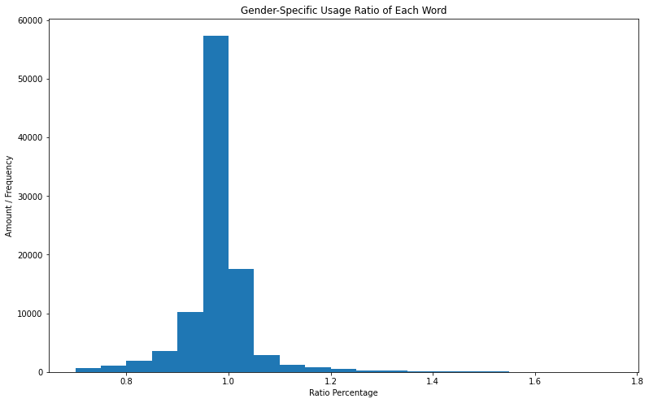

```python
import pylab as pl
graph = result["Ratio"]
graph.plot.hist(bins=np.arange(0.7, 1.8, 0.05), alpha=1, figsize = (13,8))
pl.title("Gender-Specific Usage Ratio of Each Word")
pl.xlabel("Ratio Percentage")
pl.ylabel("Amount / Frequency")
```

From this, we see most words are nearly equally used by male and female, but some words are still used by females more than males and vise versa, raising the question of if we can predict gender just by the frequency of words used by each individual

## Eliminating Noise

```python
# should get from rando data
P_F = female["gender"].count() / (female["gender"].count() + male["gender"].count())
P_M = 1 - P_F
```

```python
greater_than = (result["Ratio"] >= 0.98).to_frame()
```

```python
less_than = (result["Ratio"] <= 1.02).to_frame()
```

```python
greater_than["<=1.1"] = less_than
greater_than
```

| Words | Ratio | <=1.1 |
| --- | --- | --- |
| the | False | True |
| i | True | False |
| to | True | True |
| and | True | False |
| a | False | True |
| ... | ... | ... |
| orestes | True | True |
| dishearten | True | True |
| lotf | True | True |
| onenbspnbsp | True | True |
| shouldent | True | True |

100000 rows × 2 columns

```python
greater_than.drop(greater_than[(greater_than['Ratio'] == True) & (greater_than['<=1.1'] == True)].index, inplace=True)
```

```python
greater_than
```

| Words | Ratio | <=1.1 |
| --- | --- | --- |
| the | False | True |
| i | True | False |
| and | True | False |
| a | False | True |
| of | False | True |
| ... | ... | ... |
| wildside | False | True |
| loughlin | False | True |
| incursions | False | True |
| compas | False | True |
| tunnelling | False | True |

58525 rows × 2 columns

```python
result = result.merge(greater_than, how='right', on='Words')
```

```python
result = result.drop(['Ratio_x', 'Ratio_y', '<=1.1'], axis=1)
```

```python
test_result = result.copy()
test_result = test_result.reset_index()
```

# One word probability sample

```python
result.loc["pink"]
```

```
Female    1.533602e-12
Male      7.596810e-13
Name: pink, dtype: float64
```

```python
row = result.loc["the"]
denom = (P_M * row[1] + P_F * row[0])
P_F_given_D = (row[0] * P_F)/denom
```

```python
p_M_given_D = (row[1] * P_M)/denom
p_M_given_D
```

```
0.5496416623379982
```

```python
P_F_given_D
```

```
0.4503583376620018
```

# API

```python
def F_given_w(word):
    if word in test_result["Words"].values:
        row = result.loc[word]
        denom = (P_M * row[1] + P_F * row[0])
        P_F_given_D = (row[0] * P_F)/denom
        return P_F_given_D
    return -1
```

```python
def M_given_w(word):
    if word in test_result["Words"].values:
        row = result.loc[word]
        denom = (P_M * row[1] + P_F * row[0])
        P_M_given_D = (row[1] * P_M)/denom
        return P_M_given_D
    return -1
```

```python
def W_given_F(word):
    if word in test_result["Words"].values:
        row = result.loc[word]
        return row[0]
    # not found
    return -1
```

```python
def W_given_M(word):
    if word in test_result["Words"].values:
        row = result.loc[word]
        return row[1]
    return -1
```

# Main

## Using Naive Bayes - Program Demo

```python
text = "there exists"
text = text.split(" ")
num = 1
denom1 = 1
denom2 = 1
indx = 0
first_word = text[indx]
while W_given_F(first_word) == -1:
    indx += 1
    first_word = text[indx]
num *= P_F * pow(W_given_F(first_word), 2)
denom1 *= num
denom2 *= P_M * pow(W_given_M(first_word), 2)

text = text[indx:]
for word in text:
    if W_given_F(word) != -1:
        num *= pow(W_given_F(word), 2)
        denom1 *= pow(W_given_F(word), 2)
        denom2 *= pow(W_given_M(word), 2)
female_prob = num / (denom1 + denom2)
male_prob = 1 - female_prob

f_bool = True
if male_prob > female_prob:
    f_bool = False
    print("Male.\nProbability:", male_prob)
else:
    print("Female.\nProbability:", female_prob)
```

```
Male.
Probability: 0.8236763223235244
```

# Test - Measure accuracy of model

```python
by_gender = test.groupby(test.gender)
male = by_gender.get_group("male")
female = by_gender.get_group("female")
```

```python
P_F = female["gender"].count()/ (female["gender"].count() + male["gender"].count())
P_M = 1 - P_F
```

```python
# calculate gender for entire blog
# parameter: string
import random
def calc_gender(text):
    text = text.split(" ")
    text = list(filter(('').__ne__, text))

    all_probs = []

    for i in range(15):
        li = random.sample(text, 5)
        first_word = li[0].lower()
        first_word = re.sub('[^A-Za-z]+', '', first_word)
        while not test_result['Words'].str.contains(first_word).any() or first_word == '':
            first_word = random.choice(text).lower()
            first_word = re.sub('[^A-Za-z]+', '', first_word)
        num = 1
        denom1 = 1
        denom2 = 1
        first_val = W_given_F(first_word)

        num *= P_F * first_val * first_val
        denom1 *= num
        denom2 *= P_M * pow(W_given_M(first_word), 2)

        li = li[1:]
        set_wordbag = set()
        for word in li:
            sub = word.lower()
            sub = re.sub('[^A-Za-z]+', '', sub)
            while not test_result['Words'].str.contains(sub).any() or sub == '' or sub in set_wordbag:
                sub = random.choice(text)
                sub = sub.lower()
                sub = re.sub('[^A-Za-z]+', '', sub)
            set_wordbag.add(sub)

        for word in set_wordbag:
            val = W_given_F(word)
            if word != '' and val != -1:
                val_squared = val*val
                num *= val_squared
                denom1 *= val_squared
                denom2 *= pow(W_given_M(word), 2)

        female_prob = num / (denom1 + denom2)
        all_probs.append(female_prob)

    female_prob = sum(all_probs) / len(all_probs)
    male_prob = 1 - female_prob

    f_bool = True

    if male_prob > female_prob:
        f_bool = False

    return f_bool, female_prob
```

```python
test_result["Words"]
```

```
0               the
1                 i
2               and
3                 a
4                of
            ...
58520      wildside
58521      loughlin
58522    incursions
58523        compas
58524    tunnelling
Name: Words, Length: 58525, dtype: object
```

```python
import random

correct = 0
total = 0

print("Total:", test.shape[0])
for blog in female["text"]:
    if total % 5 == 0:
        print(total, " / ", test.shape[0], ":", total/test.shape[0], "%" )
    total += 1
    isfemale, prob = calc_gender(blog)
    if isfemale:
        correct += 1

for blog in male["text"]:
    if total % 5 == 0:
        print(total, " / ", test.shape[0], ":", total/test.shape[0], "%" )
    total += 1
    isfemale, prob = calc_gender(blog)
    if not isfemale:
        correct += 1
```

[output not shown]

```python
print("Accuracy percentage:", correct / total)
print("Num accurate:", correct)
print("Num inaccurate:", total - correct)
```

```
Accuracy percentage: 0.6731366459627329
Num accurate: 2601
Num inaccurate: 1263
```

```python
print("--- %s seconds ---" % (time.time() - start_time))
```

```
--- 28815.77236199379 seconds ---
```

# Conclusions

You cannot accurately predict gender of an author just by the words they use, according to this dataset

There are many different features that may influence speech, that is not just gender. These features may include socio-economic status, sexuality, age, location, race, etc. Also, speech entails not just the vocabulary, but the sequence of words, the sentiment, the lengths of each sentence, the length of words, etc., which I have not accounted for in my model. To further improve the accuracy, I would need more data and possibly a different approach and try to extend to more classes.

# What I've Done to Try Improve Accuracy

I squared each term to make the important words count more than the words close to 1.

Adjusted the train-test split - 80%/20% and 70%/30%

I tried to weigh words with ratios very close to 0 (range 0.9-1.1) to have very little weight by giving each female and male the same weight of their averages

Extended the dataset to 100,000 most popular words, rather than 60,000

To eliminate the issue of multiplying by 0 to the numerator and denominator terms, I've started the count at 0.00001 so that if a female uses the word and male never uses the word, the male will still hold 0.0001.

Changing Sampling Frequency:  
3 outer loop, 5 sample 0.5616977225672878  
5 outer loop, 5 sample 0.5786749482401656  
10 outer loop, 5 sample 0.5933747412008281  
15 outer loop, 5 sample 0.6233954451345756 ----- Best  
20 outer loop, 5 sample 0.6134575569358178

Changing Sample Size:  
15 outer loop, 3 sample 0.6142857142857143  
15 outer loop, 5 sample 0.6233954451345756 ----- Best  
15 outer loop, 7 sample 0.6140786749482402  
15 outer loop, 10 sample 0.6128364389233955

15 outer loop, 5 sample, removing special characters: 0.6540372670807454

Changing Operation  
Average, 15 outer loop, 5 sample: 0.6540372670807454  
Max, 15 outer loop, 5 sample: 0.5072463768115942  
Median, 15 outer loop, 5 sample: 0.6358178053830228

# Program Demo

```python
text = input("Enter text > 5 words: ")
result, prob = calc_gender(text)
if result:
    print("Female:", prob, "%")
else:
    print("Male:", prob, "%")
```

```
Enter text > 5 words: hello girl my name is jenny
Female: 0.7772771766556655 %
```